# Revisiting Ageing Error for the 2022 GOA FHS Assessment

Author

Cole Monnohan, Maia S. Kapur

## Background

This document provides the methodology, rationale and script to reproduce the analysis that generated the new ageing error matrix passed to Stock Synthesis for the 2022 assessment, which was requested by the SSC. This effort was started by C. Monnohan in Summer 2021 and continued by M S Kapur the following year.

The data used are a matrix of GOA FHS double-reads from the AFSC Age & Growth lab, provided to C. Monnohan by D. Anderl summer of 2021. Here is what those data look like. We remove rows which have no test-reader, and a single outlier case:

```r
## Read in and prep the data
dat <- read.csv("C:/Users/maia.kapur/Work/assessments/2022/goa-fhs-2022/data/ageing_error/all goa flathead sole.csv") %>%
  select(fish_id, year=collection_year,
         type=collection_type,
         length, weight, sex,
         read_age, test_age, reader_name, tester_name)

## Some basic filtering of missing (no tester) and one outlier
dat <- filter(dat, !is.na(test_age) & !is.na(read_age))
dat <- filter(dat, fish_id!=551023)
```

**Length vs. Read Age**

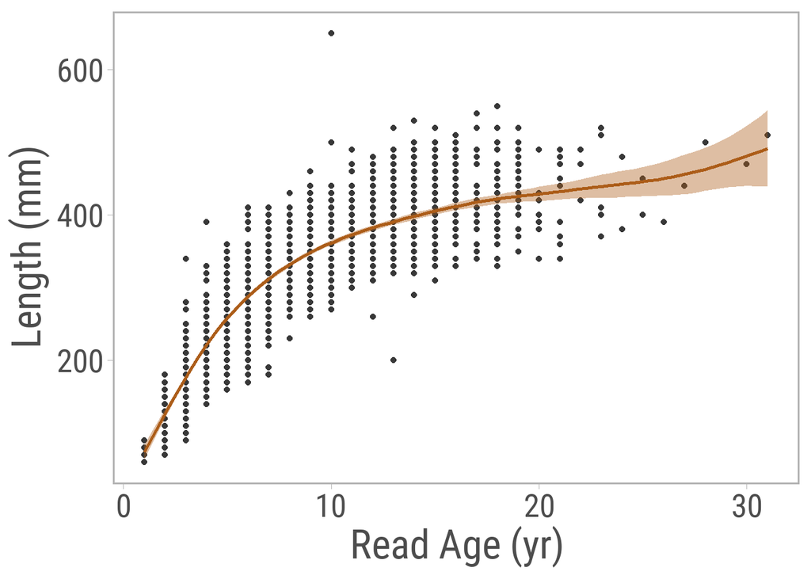

**Weight vs. Read Age**

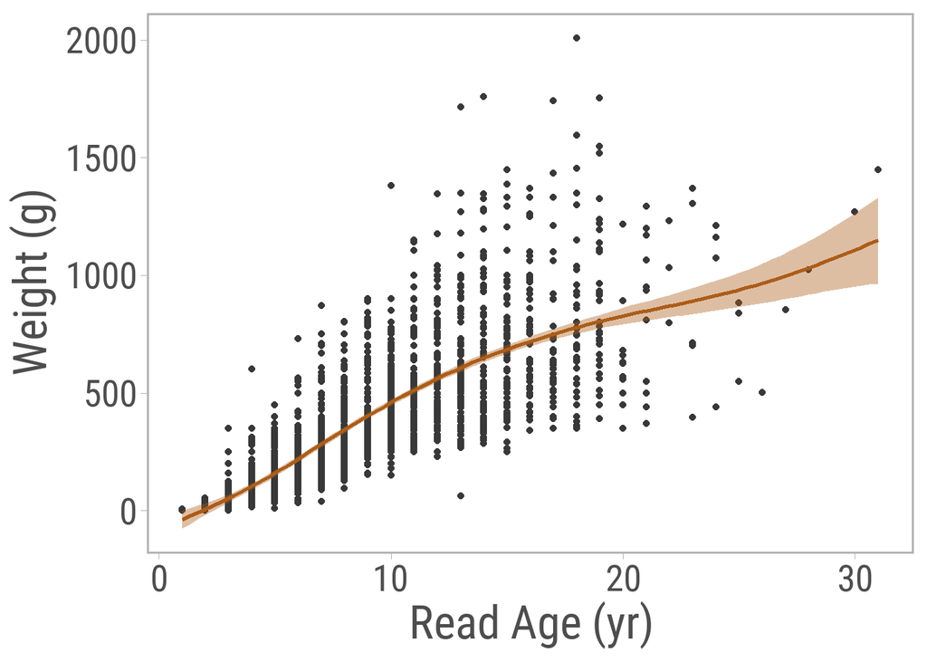

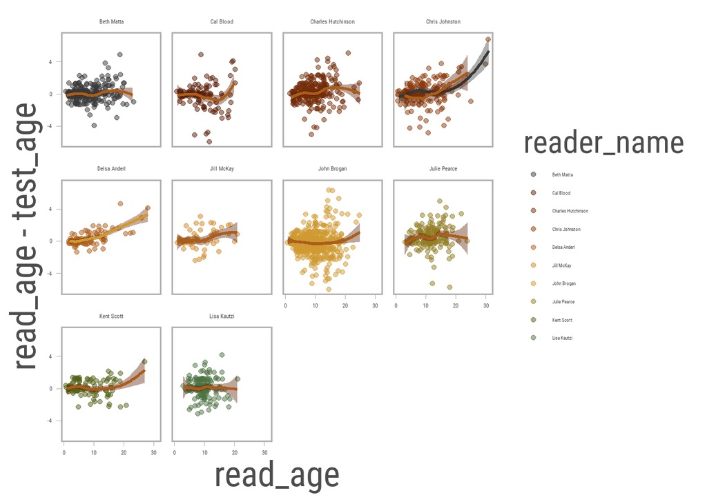

**Number of reads by reader**

```
# A tibble: 10 × 2
   reader_name        reads
   <chr>              <int>
 1 John Brogan          712
 2 Charles Hutchinson   298
 3 Beth Matta           296
 4 Chris Johnston       203
 5 Julie Pearce         171
 6 Lisa Kautzi          155
 7 Kent Scott           113
 8 Cal Blood            109
 9 Delsa Anderl          98
10 Jill McKay            63
```

**Number of tests by tester**

```
# A tibble: 3 × 2
  tester_name  reads
  <chr>        <int>
1 Beth Matta     153
2 Delsa Anderl  1967
3 John Brogan     98
```

```
                     Beth Matta Delsa Anderl John Brogan
  Beth Matta                  0          296           0
  Cal Blood                   0          109           0
  Charles Hutchinson          0          298           0
  Chris Johnston            153           50           0
  Delsa Anderl                0            0          98
  Jill McKay                  0           63           0
  John Brogan                 0          712           0
  Julie Pearce                0          171           0
  Kent Scott                  0          113           0
  Lisa Kautzi                 0          155           0
```

## Analytical Approach

We use the Punt et. al. (2008) approach as implemented in the `nwfscAgeingError` package.

We created several candidate models that either treated the individual readers separately (there are ~10 of them) or pooled the data (meaning the difference between a read by Delsa & Jon is equivalent to the difference between Tom & Mary). We use AIC to select among candidate models.

```r
## function to calculate AIC
 calc.aic <- function(RunFile, dat){
  Df <- as.numeric(scan(file.path(RunFile, "agemat.par"), comment.char = "%", what = "character",
                        quiet = TRUE)[6])
  Nll <- as.numeric(scan(file.path(RunFile, "agemat.par"), comment.char = "%", what = "character",
                         quiet = TRUE)[11])
  n <- sum(ifelse(dat[, -1] == -999, 0, 1))
  Aic <- 2 * Nll + 2 * Df
  Aicc <- Aic + 2 * Df * (Df + 1)/(n - Df - 1)
  return(Aicc)
}
```

```r
## Wrangle this into wide format needed for the model
## input. First drop and rename some columns to make this a bit
## easier
dat.long <- select(dat, -length, -weight, -type, -sex, -year,
                   age_reader1=read_age, age_reader2=test_age,
                   name_reader1=reader_name, name_reader2=tester_name)
## Then combine the two reads into long format
dat.long <- dat.long %>%
  pivot_longer(!fish_id,
               names_to=c(".value", "reader"),
               names_sep="_")
## Now cast it wider again, where -999 is the ADMB code for no
## read. This is now a row for each fish, with columns for each
## potential reader, and values are the ages.
dat.wide <- pivot_wider(dat.long, fish_id, names_from='name',
                        values_from='age',
                        values_fill=-999) %>% clean_names
## Sum duplicate rows b/c that's needed by model. Drop fish_id now.
dat.mat <- dat.wide[,-1] %>% janitor::get_dupes(everything()) %>%
  ## Rearrange columns.
  select(dupe_count, everything())
## Drop duplicates and convert to matrix. This is final data set
dat.mat <- dat.mat[!duplicated(dat.mat),] %>% as.matrix

### ------------------------------------------------------------
### Repeat this but collapse down into two readers, essentially
### assuming that all readers are equivalent and unbiased
dat2.wide <- pivot_wider(dat.long, fish_id, names_from='reader',
                        values_from='age')
## Sum duplicate rows b/c that's needed by model. Drop fish_id now.
dat2.mat <- dat2.wide[,-1] %>% janitor::get_dupes(everything()) %>%
  ## Rearrange columns.
  select(dupe_count, everything())
## Drop duplicates and convert to matrix. This is final dat2a set
dat2.mat <- dat2.mat[!duplicated(dat2.mat),] %>% as.matrix

n.readers <- ncol(dat.mat)-1

## To simplify code a bit write a quick wrapper fn
run_model <- function(sig, bias, knotages=NULL, dat=dat.mat, modname = 'mod1'){
  ## Dummy values when not using feature
  if(is.null(knotages)) knotages <- rep(list(c(2,8, 15,25)), times=length(sig))
  # savehere = here("data", "ageing_error","real_data", modname)
  dir.create(savehere)
  RunFn(Data=dat,
        SigOpt=sig, BiasOpt=bias, KnotAges=knotages,
        NDataSets=1, MinAge=1, MaxAge=29, RefAge=10,
        MinusAge=1, PlusAge=21,
        # SaveFile='real_data',
        SaveFile=savehere,
        AdmbFile= here("data", "ageing_error"),
        # AdmbFile=system.file("executables", package="nwfscAgeingError"),
        EffSampleSize=0)
  # setwd("c:/Users/cole.monnahan/Work/assessments/GOA_flathead/2021_GOA_flathead/ageing_error")
  aic <- calc.aic(savehere, dat)
  PlotOutputFn(Data = dat2.mat, MaxAge = 29,
               SaveFile = savehere,  PlotType = "PNG")
  aic
}

# if(!exists(dir(here("data","ageing_error",'real_data'))) dir.create("real_data", showWarnings=FALSE)
## Full bias and sigma terms
aic1 <- run_model(sig=rep(2, n.readers), bias=rep(2, n.readers),modname = 'aic1')
## Single sigma term, full bias
aic2 <- run_model(sig=c(2,-1,-2,-3,-4,-5,-6,-7,-8,-9),
                  bias=rep(2, n.readers),modname = 'aic2')
## Single bias term, full sigma
aic3 <- run_model(sig=c(2,-1,-2,-3,-4,-5,-6,-7,-8,-9),
                  bias=rep(2, n.readers),modname = 'aic3')
## Single sigma and bias term
aic4 <- run_model(sig=c(2,-1,-2,-3,-4,-5,-6,-7,-8,-9),
                  bias=c(2,-1,-2,-3,-4,-5,-6,-7,-8,-9),modname = 'aic4')
## Single sigma and no bias term but with spline
aic5 <- run_model(sig=c(5,-1,-2,-3,-4,-5,-6,-7,-8,-9),
                  bias=c(0,-1,-2,-3,-4,-5,-6,-7,-8,-9),
                  knotages=rep(list(c(1,4,8,12,16)),10),modname = 'aic5')
## Ian S recommends no bias and pooled readers
## Single sigma and bias term
aic6 <- run_model(sig=c(2,-1,-2,-3,-4,-5,-6,-7,-8,-9),
                  bias=c(0,-1,-2,-3,-4,-5,-6,-7,-8,-9),modname = 'aic6')
aics <- c(aic1, aic2, aic3, aic4, aic5, aic6)
aics-min(aics)
which.min(aics) ## this is the single sigma and bias term

# PlotOutputFn(Data = dat.mat, MaxAge = 29,
#              SaveFile = 'real_data', PlotType = "PNG")

### This uses the pooled data
aic1p <- run_model(sig=c(2,-1), bias=c(2,-1), dat=dat2.mat,modname = 'aic1p')
aic2p <- run_model(sig=c(2,-1), bias=c(0,0), dat=dat2.mat,modname = 'aic2p')
aic3p <- run_model(sig=c(1,-1), bias=c(0,0), dat=dat2.mat,modname = 'aic3p')
aic4p <- run_model(sig=c(5,-1), bias=c(0,0),
                  rep(list(c(1,4,8,12,16, 20)),2), ## age knots
                  dat=dat2.mat,modname = 'aic4p')
aicsp <- c(aic1p, aic2p, aic3p, aic4p)
aicsp-min(aicsp)
which.min(aicsp)

## looks like aic2p and 4p are identical... which is likely why cole stuck with 2p


## Do some manual processing of selected model
xx <- readLines( here("data", "ageing_error","real_data","aic2p","AGEMAT.rep"))
l1 <- grep("Reader Age CV SD Expected age", xx)+1
l2 <- grep("Estimated age-structure by data set", xx)-2
out <- do.call(rbind, strsplit(xx[l1:l2], ' ')) %>% as.data.frame %>%
  mutate_if(is.character, as.numeric) %>%
  setNames(c('reader', 'age', 'CV', 'SD', 'expected_age')) %>%
  mutate(reader=as.factor(reader)) %>%
  filter(expected_age<25)

p1 <- ggplot(out, aes(expected_age, age-expected_age,
                color=reader, fill=reader,
                ymin=age-SD-expected_age,
                ymax=age+SD-expected_age))+
  geom_line() +
  geom_ribbon(alpha=.3) +
  coord_cartesian(ylim=c(-10,10)) +  scale_color_manual(values = docPal) +
  scale_fill_manual(values = docPal) +theme(legend.position = 'none')
p2 <- ggplot(out, aes(expected_age, CV, color=reader)) + geom_line() +  scale_color_manual(values = docPal) +
  scale_fill_manual(values = docPal)


require(patchwork)
ggsave(p1 | p2,  file = here("data", "ageing_error","real_data","aic2p","compplots.png"))
```

# Summary Figures 1: New Ageing Error Matrix for GOA FHS

**Estimated vs. Observed Age Structure**

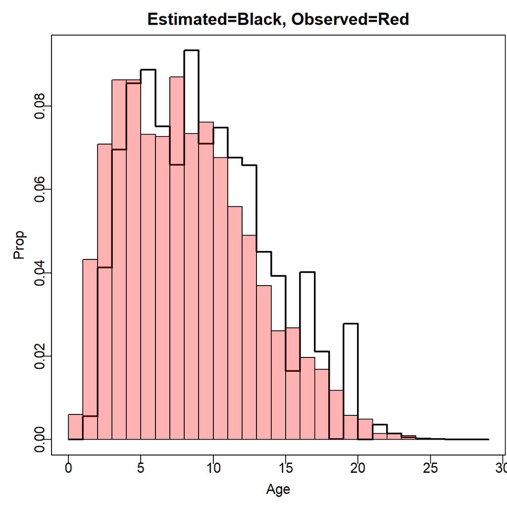

Overall age structure comparison between observed and read ages, with data specific to GOA FHS.

**Reader 1 vs Reader 2**

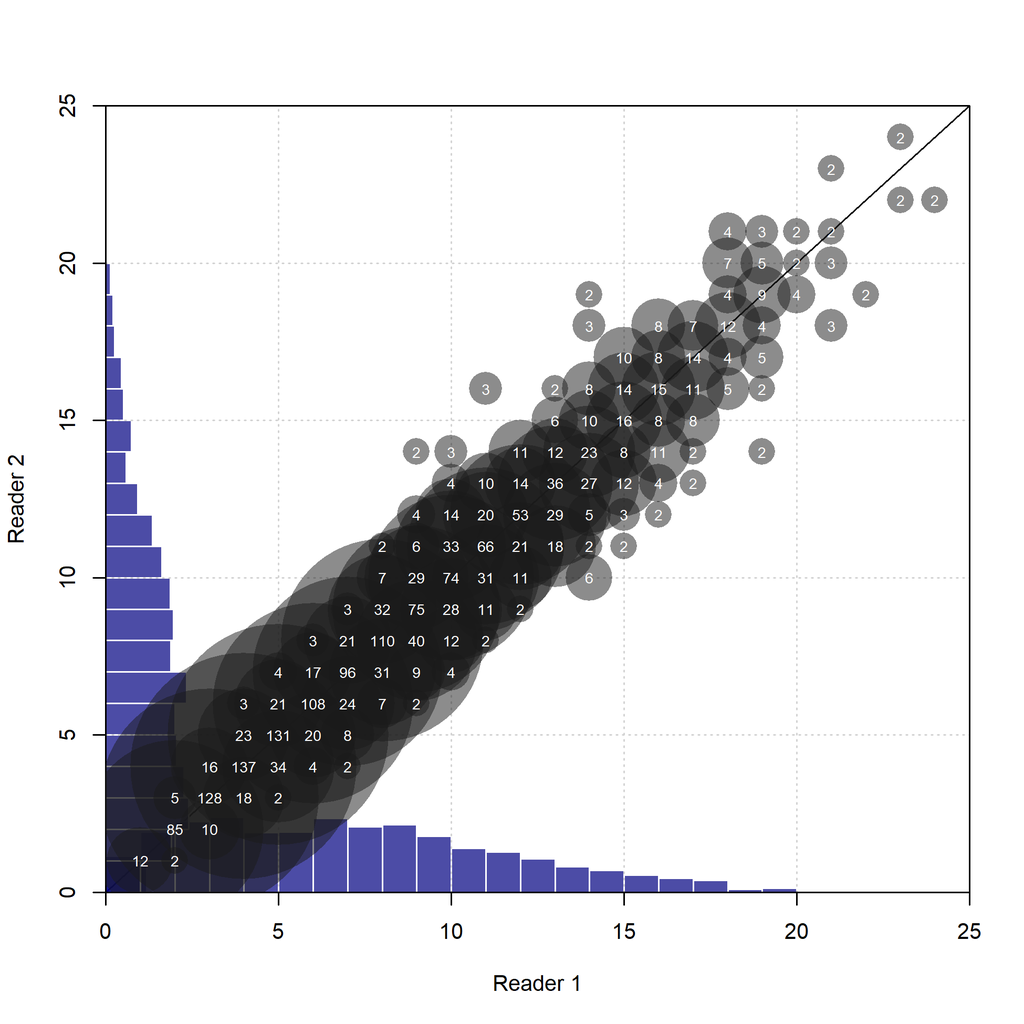

Distribution of age reads among reader-pairs. Numbers within bubbles indicate sample size. Black line indicates identiy (agreement between readers). Blue histograms indicate the number of reads at each given age bin.

**True Age vs Reads, by Reader**

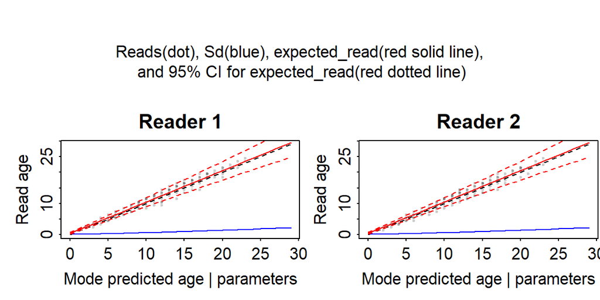

True age vs Read age, by reader, and associated SD. These data are specific to GOA FHS.

**Comparison Plots**

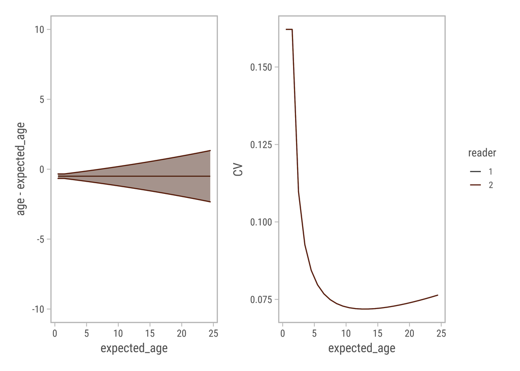

Observed error in age reads vs age, by reader.

# Summary Figures 2: Comparison between Matrices

**Old vs New Ageing Error Matrix**

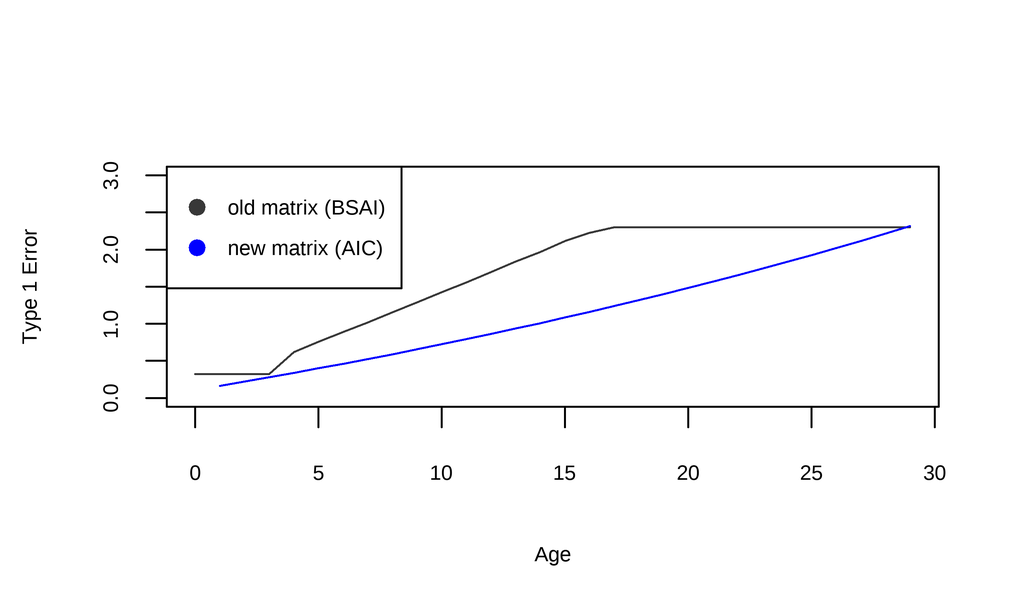

Ageing error matrix used in the 2017 base model (black line) and new ageing error matrix selected via AIC under the Punt et. al. (2008) approach (blue lines). The new matrix uses data specific to GOA FHS and suggests a linear increase in aging error through bin 29.

**Comparing Matrices within Model 17.1a**

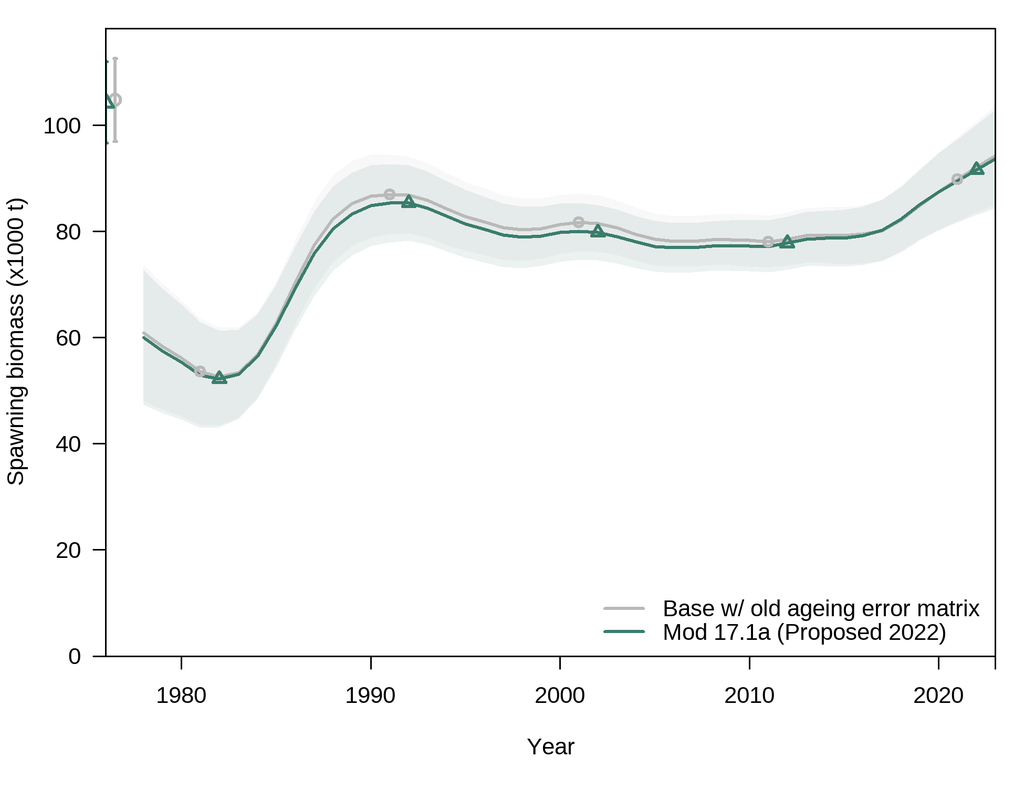

SSB, recruitment deviations, and fits to the survey time series for the proposed 2022 base model (17.1a) with the new aging error matrix (green lines and points) and the previous matrix (grey lines and points). The differences in fits and derived quantities are fairly negligible.

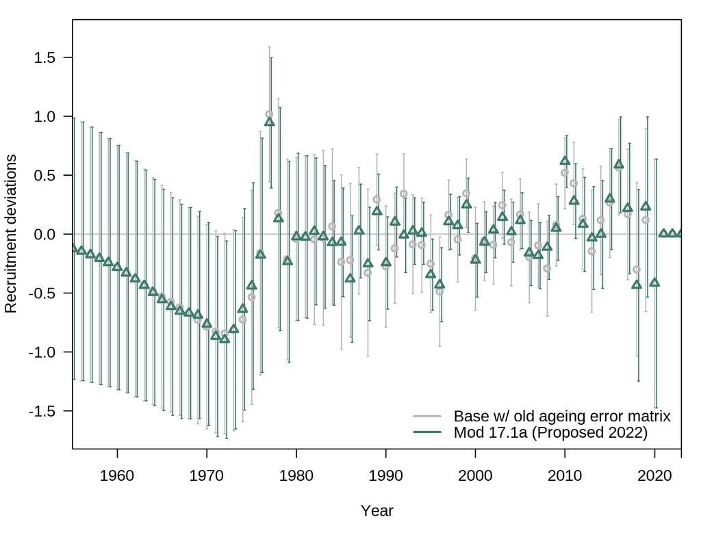

SSB, recruitment deviations, and fits to the survey time series for the proposed 2022 base model (17.1a) with the new aging error matrix (green lines and points) and the previous matrix (grey lines and points). The differences in fits and derived quantities are fairly negligible.

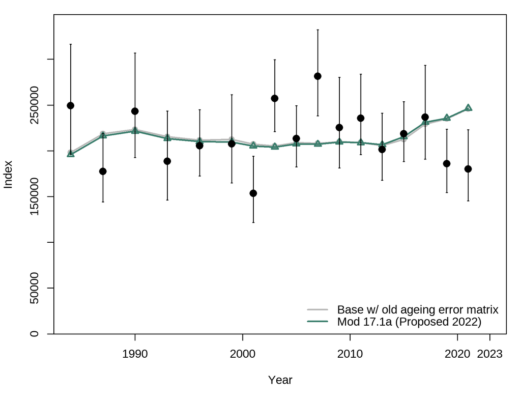

SSB, recruitment deviations, and fits to the survey time series for the proposed 2022 base model (17.1a) with the new aging error matrix (green lines and points) and the previous matrix (grey lines and points). The differences in fits and derived quantities are fairly negligible.